# Reproducible Research: Peer Assessment 2

Chongyuan Xu

April, 20th, 2015

# Impact of Health and Economic of Weather Events in USA

## Synopsis

Storms and other severe weather events can cause both public health and economic problems for communities and municipalities. Many severe events can result in fatalities, injuries, and property damage, and preventing such outcomes to the extent possible is a key concern. This project involves exploring the U.S. National Oceanic and Atmospheric Administration’s (NOAA) storm database. This database tracks characteristics of major storms and weather events in the United States, including when and where they occur, as well as estimates of any fatalities, injuries, and property damage. In this assessment, I want to find which types of events (as indicated in the EVTYPE variable) are most harmful with respect to population health and which types of events have the greatest economic consequences.

## Data Processing

Load the data

```r
data <- read.csv(bzfile("repdata-data-StormData.csv.bz2"), header = TRUE, stringsAsFactors = FALSE)
head(data)
```

```
##   STATE__           BGN_DATE BGN_TIME TIME_ZONE COUNTY COUNTYNAME STATE
## 1       1  4/18/1950 0:00:00     0130       CST     97     MOBILE    AL
## 2       1  4/18/1950 0:00:00     0145       CST      3    BALDWIN    AL
## 3       1  2/20/1951 0:00:00     1600       CST     57    FAYETTE    AL
## 4       1   6/8/1951 0:00:00     0900       CST     89    MADISON    AL
## 5       1 11/15/1951 0:00:00     1500       CST     43    CULLMAN    AL
## 6       1 11/15/1951 0:00:00     2000       CST     77 LAUDERDALE    AL
##    EVTYPE BGN_RANGE BGN_AZI BGN_LOCATI END_DATE END_TIME COUNTY_END
## 1 TORNADO         0                                               0
## 2 TORNADO         0                                               0
## 3 TORNADO         0                                               0
## 4 TORNADO         0                                               0
## 5 TORNADO         0                                               0
## 6 TORNADO         0                                               0
##   COUNTYENDN END_RANGE END_AZI END_LOCATI LENGTH WIDTH F MAG FATALITIES
```

[output cut: 20 more lines]

```r
names(data)
```

```
##  [1] "STATE__"    "BGN_DATE"   "BGN_TIME"   "TIME_ZONE"  "COUNTY"
##  [6] "COUNTYNAME" "STATE"      "EVTYPE"     "BGN_RANGE"  "BGN_AZI"
## [11] "BGN_LOCATI" "END_DATE"   "END_TIME"   "COUNTY_END" "COUNTYENDN"
## [16] "END_RANGE"  "END_AZI"    "END_LOCATI" "LENGTH"     "WIDTH"
## [21] "F"          "MAG"        "FATALITIES" "INJURIES"   "PROPDMG"
## [26] "PROPDMGEXP" "CROPDMG"    "CROPDMGEXP" "WFO"        "STATEOFFIC"
## [31] "ZONENAMES"  "LATITUDE"   "LONGITUDE"  "LATITUDE_E" "LONGITUDE_"
## [36] "REMARKS"    "REFNUM"
```

There are just 7 variables of the storm data needed in this analysis: - EVTYPE: All the events listed. - FATALITIES: The number of people died during an event. - INJURIES: The number of people injured during an event. - PROPDMG: The amount of property damage. - PROPDMGEXP: the order of magnitudes of PROPDMG. - CROPDMG: the amount of crop damage. - CROPDMGEXP: the order of magnitudes of CROPDMG.

We should calculate the total amount of property damage and crop damage in US dollars.

```r
unique(data$PROPDMGEXP)
```

```
##  [1] "K" "M" ""  "B" "m" "+" "0" "5" "6" "?" "4" "2" "3" "h" "7" "H" "-"
## [18] "1" "8"
```

```r
data$PROPDMGEXP <- as.character(data$PROPDMGEXP)
data$PROPDMGEXP[which(data$PROPDMGEXP == "K")] <- 1e+03
data$PROPDMGEXP[which(data$PROPDMGEXP == "M")] <- 1e+06
data$PROPDMGEXP[which(data$PROPDMGEXP == "")] <- 1
data$PROPDMGEXP[which(data$PROPDMGEXP == "B")] <- 1e+09
data$PROPDMGEXP[which(data$PROPDMGEXP == "m")] <- 1e+06
data$PROPDMGEXP[which(data$PROPDMGEXP == "+")] <- 0
data$PROPDMGEXP[which(data$PROPDMGEXP == "0")] <- 1
data$PROPDMGEXP[which(data$PROPDMGEXP == "5")] <- 1e+05
data$PROPDMGEXP[which(data$PROPDMGEXP == "6")] <- 1e+06
data$PROPDMGEXP[which(data$PROPDMGEXP == "?")] <- 0
data$PROPDMGEXP[which(data$PROPDMGEXP == "4")] <- 1e+04
data$PROPDMGEXP[which(data$PROPDMGEXP == "2")] <- 1e+02
data$PROPDMGEXP[which(data$PROPDMGEXP == "3")] <- 1e+03
data$PROPDMGEXP[which(data$PROPDMGEXP == "h")] <- 1e+02
data$PROPDMGEXP[which(data$PROPDMGEXP == "7")] <- 1e+07
data$PROPDMGEXP[which(data$PROPDMGEXP == "H")] <- 1e+02
data$PROPDMGEXP[which(data$PROPDMGEXP == "-")] <- 0
data$PROPDMGEXP[which(data$PROPDMGEXP == "1")] <- 10
data$PROPDMGEXP[which(data$PROPDMGEXP == "8")] <- 1e+08
data$PROPDMGAMOUNT <- data$PROPDMG * as.numeric(data$PROPDMGEXP)
```

```r
unique(data$CROPDMGEXP)
```

```
## [1] ""  "M" "K" "m" "B" "?" "0" "k" "2"
```

```r
data$CROPDMGEXP <- as.character(data$CROPDMGEXP)
data$CROPDMGEXP[which(data$CROPDMGEXP == "")] <- 1
data$CROPDMGEXP[which(data$CROPDMGEXP == "M")] <- 1e+06
data$CROPDMGEXP[which(data$CROPDMGEXP == "K")] <- 1e+03
data$CROPDMGEXP[which(data$CROPDMGEXP == "m")] <- 1e+06
data$CROPDMGEXP[which(data$CROPDMGEXP == "B")] <- 1e+09
data$CROPDMGEXP[which(data$CROPDMGEXP == "?")] <- 0
data$CROPDMGEXP[which(data$CROPDMGEXP == "0")] <- 1
data$CROPDMGEXP[which(data$CROPDMGEXP == "k")] <- 1e+03
data$CROPDMGEXP[which(data$CROPDMGEXP == "2")] <- 1e+02
data$CROPDMGAMOUNT <- data$CROPDMG * as.numeric(data$CROPDMGEXP)
```

Then, we must calculate the sum of fatilities, injuries, proper damage amount and crop damage amount for each kind of event.

```r
Fatalities <- aggregate(data$FATALITIES, by = list(data$EVTYPE), FUN = sum)
names(Fatalities) <- c("EVTYPE", "FATALITIES")

Injuries <- aggregate(data$INJURIES, by = list(data$EVTYPE), FUN = sum)
names(Injuries) <- c("EVTYPE", "INJURIES")

Propdmgamount <- aggregate(data$PROPDMGAMOUNT, by = list(data$EVTYPE), FUN = sum)
names(Propdmgamount) <- c("EVTYPE", "PROPDMGAMOUNT")

Cropdmgamount <- aggregate(data$CROPDMGAMOUNT, by = list(data$EVTYPE), FUN = sum)
names(Cropdmgamount) <- c("EVTYPE", "CROPDMGAMOUNT")
```

## Results

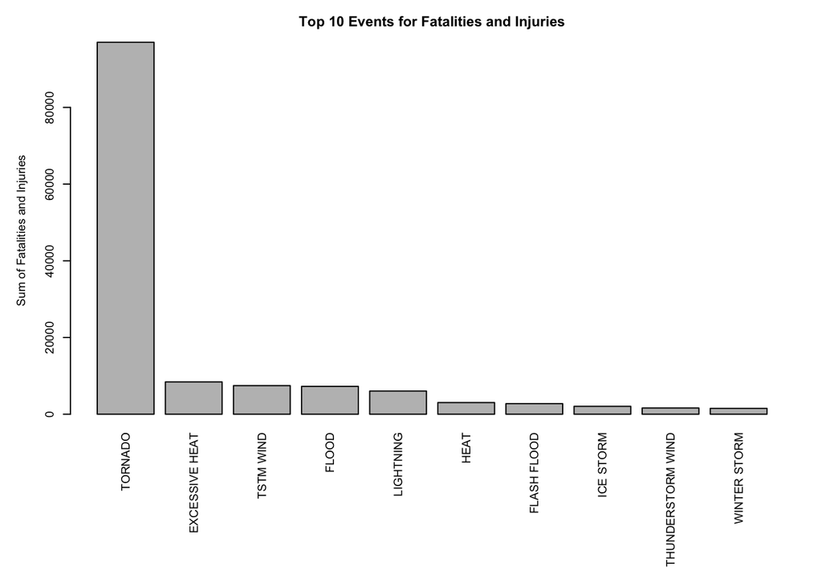

```r
library(ggplot2)
FatalitiesInjuries <- data.frame(Fatalities$EVTYPE, Fatalities$FATALITIES + Injuries$INJURIES)
names(FatalitiesInjuries) <- c("EVTYPE", "FATALITIESINJURIES")
FatalitiesInjuries <- FatalitiesInjuries[order(-FatalitiesInjuries$FATALITIESINJURIES)[1 : 10], ]

par(mfrow = c(1, 1), mar = c(12, 5, 3, 2), mgp = c(3, 1, 0), cex = 0.6, las = 3)
barplot(FatalitiesInjuries[, 2], names.arg = FatalitiesInjuries$EVTYPE, main = 'Top 10 Events for Fatalities and Injuries', ylab = "Sum of Fatalities and Injuries")
```

It is easily seen from the graph that the most harmful event respect to population health is tornado, which has much more fatalities and injuries than any other event.

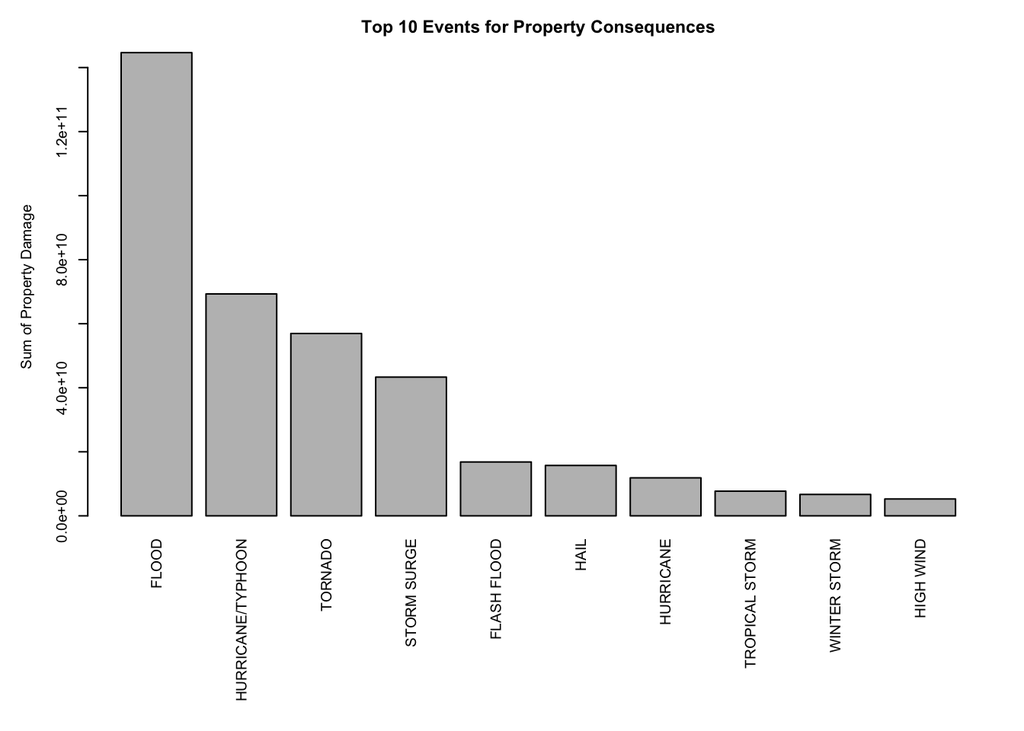

```r
Propdmgamount <- Propdmgamount[order(-Propdmgamount$PROPDMGAMOUNT)[1 : 10], ]

par(mfrow = c(1, 1), mar = c(12, 5, 3, 2), mgp = c(3, 1, 0), cex = 0.6, las = 3)
barplot(Propdmgamount[, 2], names.arg = Propdmgamount$EVTYPE, main = 'Top 10 Events for Property Consequences', ylab = "Sum of Property Damage")
```

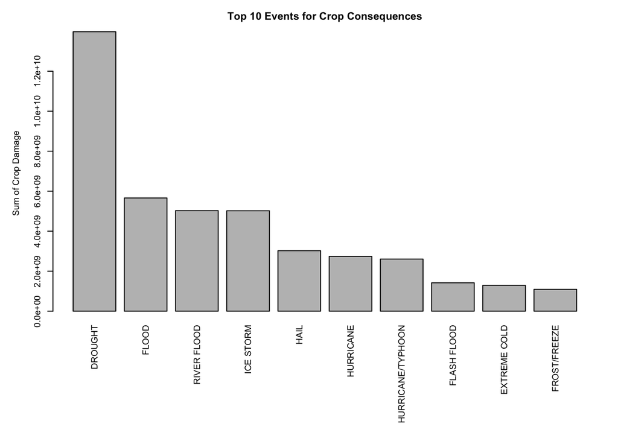

```r
Cropdmgamount <- Cropdmgamount[order(-Cropdmgamount$CROPDMGAMOUNT)[1 : 10], ]

par(mfrow = c(1, 1), mar = c(12, 5, 3, 2), mgp = c(3, 1, 0), cex = 0.6, las = 3)
barplot(Cropdmgamount[, 2], names.arg = Cropdmgamount$EVTYPE, main = 'Top 10 Events for Crop Consequences', ylab = "Sum of Crop Damage")
```

We can find that flood, hurricane/typhoon and tornado are the events that mostly affect the property. Drought, flood and river flood are the events that mostly effect the crop.